# Credit_Risk_And_Default_Prediction_Project

```python
pip install missingno
```

```python
pip install sweetviz
```

```python
pip install optuna-integration
```

```python
pip install shap
```

```python
pip install catboost
```

```python
pip install lightgbm
```

# EDA for Credit Risk & Default Prediction

```python
import pandas as pd
import numpy as np
import matplotlib.pyplot as plt
import plotly.express as px
import seaborn as sns
import sweetviz as sv
import optuna
from optuna.visualization import plot_optimization_history, plot_slice, plot_contour
import shap
import xgboost
import missingno as msno
from xgboost import XGBClassifier
from decimal import Decimal
from imblearn.over_sampling import ADASYN, SMOTE
from sklearn.preprocessing import OneHotEncoder, OrdinalEncoder, LabelEncoder, TargetEncoder
from sklearn.preprocessing import StandardScaler, MinMaxScaler, FunctionTransformer, PowerTransformer
from imblearn.pipeline import Pipeline
from sklearn.compose import ColumnTransformer, make_column_selector
from sklearn.decomposition import PCA
from sklearn.impute import SimpleImputer
from sklearn.model_selection import train_test_split, cross_val_score
from sklearn.metrics import classification_report, roc_auc_score, confusion_matrix, ConfusionMatrixDisplay
from sklearn.utils.class_weight import compute_sample_weight
from sklearn.preprocessing import Binarizer
from sklearn.model_selection import TunedThresholdClassifierCV
from sklearn.preprocessing import PowerTransformer
from sklearn.model_selection import validation_curve
from sklearn.ensemble import VotingClassifier
import lightgbm as lgb
from catboost import CatBoostClassifier, Pool
```

```python
df = pd.read_csv('train.csv')
```

```python
df.head(10)
```

|  | Id | age | number_dependent_family_members | monthly_income | number_of_credit_lines | real_estate_loans | ratio_debt_payment_to_income | credit_line_utilization | number_of_previous_late_payments_up_to_59_days | number_of_previous_late_payments_up_to_89_days | number_of_previous_late_payments_90_days_or_more | defaulted_on_loan |
| --- | --- | --- | --- | --- | --- | --- | --- | --- | --- | --- | --- | --- |
| 0 | 1 | 66.0 | NaN | 4000.0 | NaN | 1.0 | 0.569108 | 0.05488766900000001 | 0.0 | 0.0 | 0.0 | 0 |
| 1 | 2 | 61.0 | 2.0 | 4000.0 | 6.0 | 1.0 | 0.297176 | 0.10194991099999999 | 0.0 | 0.0 | 0.0 | 0 |
| 2 | 3 | 31.0 | 2.0 | 3040.0 | 8.0 | 0.0 | 0.160145 | 1.22713507 | 4.0 | 0.0 | 0.0 | 1 |
| 3 | 4 | 54.0 | 4.0 | 10218.0 | 5.0 | 0.0 | 0.067913 | 0.08327777900000001 | 0.0 | 0.0 | 0.0 | 0 |
| 4 | 5 | 29.0 | 0.0 | 4468.0 | 6.0 | 0.0 | 0.328261 | 0.317445504 | 0.0 | 0.0 | 0.0 | 0 |
| 5 | 6 | 39.0 | 2.0 | 4166.0 | 17.0 | 1.0 | NaN | NaN | 1.0 | 0.0 | 0.0 | 0 |
| 6 | 7 | 30.0 | 2.0 | 4585.0 | 1.0 | 0.0 | 0.087004 | 0.9999998999999999 | 1.0 | NaN | 4.0 | 0 |
| 7 | 8 | NaN | 0.0 | 2916.0 | 5.0 | 0.0 | 0.124100 | 0.06742675599999999 | 0.0 | 0.0 | 0.0 | 0 |
| 8 | 9 | 51.0 | 2.0 | 3836.0 | 9.0 | 0.0 | 0.208496 | NaN | 0.0 | 0.0 | 0.0 | 0 |
| 9 | 10 | 60.0 | 0.0 | 2900.0 | 5.0 | 1.0 | NaN | NaN | 0.0 | 0.0 | 0.0 | 0 |

```python
df.info()
```

```
<class 'pandas.core.frame.DataFrame'>
RangeIndex: 72161 entries, 0 to 72160
Data columns (total 12 columns):
 #   Column                                            Non-Null Count  Dtype
---  ------                                            --------------  -----
 0   Id                                                72161 non-null  int64
 1   age                                               65017 non-null  float64
 2   number_dependent_family_members                   67945 non-null  float64
 3   monthly_income                                    66145 non-null  float64
 4   number_of_credit_lines                            66007 non-null  float64
 5   real_estate_loans                                 68355 non-null  float64
 6   ratio_debt_payment_to_income                      66553 non-null  float64
 7   credit_line_utilization                           65815 non-null  object
 8   number_of_previous_late_payments_up_to_59_days    67966 non-null  float64
 9   number_of_previous_late_payments_up_to_89_days    66316 non-null  float64
 10  number_of_previous_late_payments_90_days_or_more  68540 non-null  float64
 11  defaulted_on_loan                                 72161 non-null  int64
dtypes: float64(9), int64(2), object(1)
memory usage: 6.6+ MB
```

```python
df.describe()
```

|  | Id | age | number_dependent_family_members | monthly_income | number_of_credit_lines | real_estate_loans | ratio_debt_payment_to_income | number_of_previous_late_payments_up_to_59_days | number_of_previous_late_payments_up_to_89_days | number_of_previous_late_payments_90_days_or_more | defaulted_on_loan |
| --- | --- | --- | --- | --- | --- | --- | --- | --- | --- | --- | --- |
| count | 72161.000000 | 65017.000000 | 67945.000000 | 6.614500e+04 | 66007.000000 | 68355.000000 | 66553.000000 | 67966.000000 | 66316.000000 | 68540.000000 | 72161.000000 |
| mean | 36081.000000 | 51.388914 | 0.847009 | 6.624388e+03 | 8.756193 | 1.050296 | 26.524005 | 0.393491 | 0.206074 | 0.224059 | 0.069470 |
| std | 20831.230725 | 14.414338 | 1.144038 | 1.084630e+04 | 5.198769 | 1.114420 | 399.253008 | 3.680686 | 3.696260 | 3.634436 | 0.254253 |
| min | 1.000000 | 21.000000 | 0.000000 | 0.000000e+00 | 0.000000 | 0.000000 | 0.000000 | 0.000000 | 0.000000 | 0.000000 | 0.000000 |
| 25% | 18041.000000 | 41.000000 | 0.000000 | 3.400000e+03 | 5.000000 | 0.000000 | 0.141302 | 0.000000 | 0.000000 | 0.000000 | 0.000000 |
| 50% | 36081.000000 | 51.000000 | 0.000000 | 5.400000e+03 | 8.000000 | 1.000000 | 0.294673 | 0.000000 | 0.000000 | 0.000000 | 0.000000 |
| 75% | 54121.000000 | 62.000000 | 2.000000 | 8.232000e+03 | 11.000000 | 2.000000 | 0.480989 | 0.000000 | 0.000000 | 0.000000 | 0.000000 |
| max | 72161.000000 | 103.000000 | 13.000000 | 1.560100e+06 | 57.000000 | 25.000000 | 61106.500000 | 98.000000 | 98.000000 | 98.000000 | 1.000000 |

### Deleting the ID column, as it is not needed for analysis

```python
df.drop(columns='Id', inplace=True)
```

### Checking one feature of the object type for content

```python
df['credit_line_utilization'].apply(type).value_counts()
```

```
credit_line_utilization
<class 'str'>      65815
<class 'float'>     6346
Name: count, dtype: int64
```

#### The column must contain data of the same type, so we convert the data to the float type

```python
converted_clu_col = df['credit_line_utilization'].str.replace(',', '.').astype(float)
converted_clu_col.apply(type).value_counts()
```

```
credit_line_utilization
<class 'float'>    72161
Name: count, dtype: int64
```

```python
df['credit_line_utilization'] = converted_clu_col
```

### Using sweetviz for quick analysis

```python
my_report = sv.analyze(df)
my_report.show_notebook()
```

```
                                             |          | [  0%]   00:00 -> (? left)
```

[interactive chart not shown]

#### Judging by the graphs, there are some errors in the three late payment features. Most of the data is in the range up to 20, although each column contains values equal to 96 and 98. Let's replace these with NaN and consider them recording errors. At the same time, adding flags for data we changed

#### We will also add information about zeros in the line, since there is a possibility of missing data that is filled with 0.

```python
late_pay_cols = ['number_of_previous_late_payments_up_to_59_days', 'number_of_previous_late_payments_up_to_89_days', 'number_of_previous_late_payments_90_days_or_more']

df['number_of_previous_late_payments_90_days_or_more_error_flagg'] = ((df['number_of_previous_late_payments_90_days_or_more'] == 98) | (df['number_of_previous_late_payments_90_days_or_more'] == 96)).astype(int)

df['missing_info_count'] = df.isnull().sum(axis=1)

for col in late_pay_cols:
    df[col] = df[col].replace({96: np.nan, 98: np.nan})
```

### Checking missings

```python
df.isna().sum()
```

```
age                                                             7144
number_dependent_family_members                                 4216
monthly_income                                                  6016
number_of_credit_lines                                          6154
real_estate_loans                                               3806
ratio_debt_payment_to_income                                    5608
credit_line_utilization                                         6346
number_of_previous_late_payments_up_to_59_days                  4288
number_of_previous_late_payments_up_to_89_days                  5939
number_of_previous_late_payments_90_days_or_more                3714
defaulted_on_loan                                                  0
number_of_previous_late_payments_90_days_or_more_error_flagg       0
missing_info_count                                                 0
dtype: int64
```

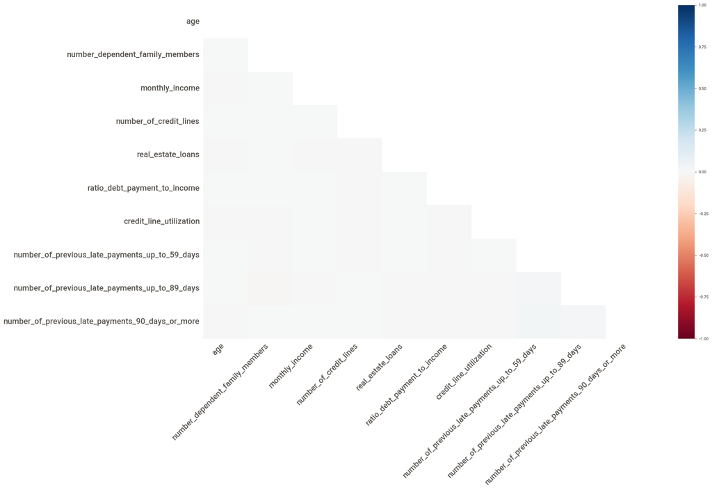

```python
msno.heatmap(df)
```

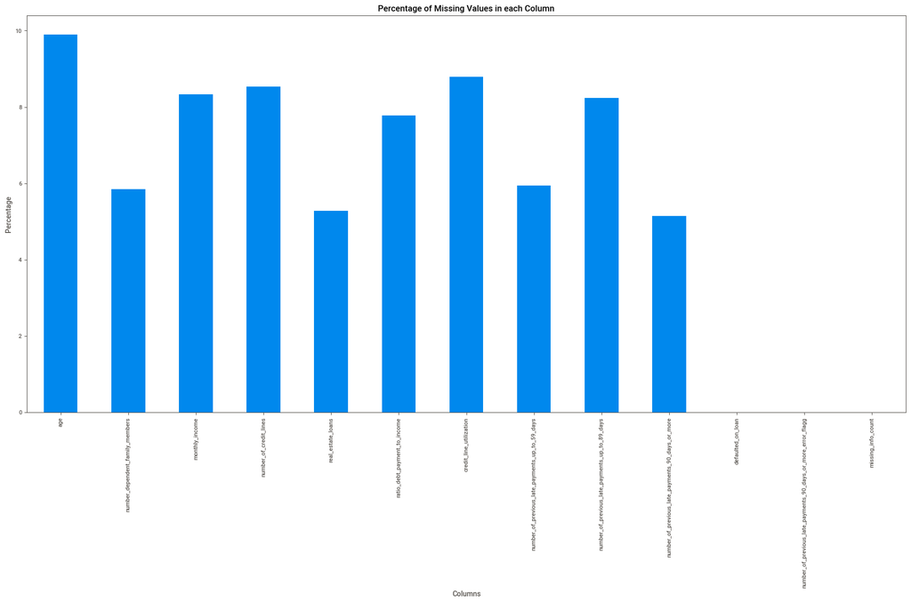

```python
plt.figure(figsize=(22, 10))
missing_percentage = df.isnull().sum()/len(df)*100
missing_percentage.plot(kind='bar')
plt.xlabel('Columns')
plt.ylabel('Percentage')
plt.title('Percentage of Missing Values in each Column')
```

#### The gaps are no more than 10 percent, so we won't delete anything. We also won't fill them in, as the selected model benefits from such data

### Checking the dataset for duplicate rows

```python
duplic_indx = df[df.duplicated()].index
duplic_indx
```

```
Index([23086, 31498, 33561, 36514, 42544, 46177, 47503, 51726, 52843, 55355,
       57246, 61259, 65123, 65217],
      dtype='int64')
```

#### Duplicates will interfere with model training, so we remove them from the dataset

```python
df.drop(index=duplic_indx, inplace=True)
```

### Looking at the distributions and outliers

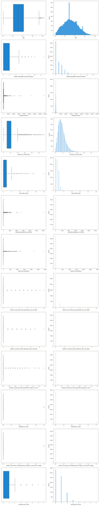

```python
df_cols = df.columns
df_cols.drop(['number_of_previous_late_payments_90_days_or_more_error_flagg'])
j = 1
plt.figure(figsize=(12, 60))
for col in df_cols:
    for i in range(0, 2):
        plt.subplot(13, 2, j)
        if i == 0:
            sns.boxplot(df, x=df[col])
        else:
            sns.histplot(df, x=df[col])
        j+=1
plt.tight_layout()
plt.show()
```

#### Features 'credit_line_utilization' and 'ratio_debt_payment_to_income' have very strong data skew. We'll use a PowerTransformer(method='yeo-johnson'), since it can work with negative and zero values, for these columns to remove the long right tail.

#### But before that, let's perform feature engineering while the data is in its original form.

```python
# Loan amount in currency
df['monthly_debt'] = df['monthly_income'].fillna(0) * df['ratio_debt_payment_to_income'].fillna(0)
# The remaining money for a month after paying off the loan
monthly_balance_after_pay = df['monthly_income'].fillna(0) - df['monthly_debt']

# Number of overdue payments with aggravation for duration
df['total_late_payments_weighted'] = 5 * df['number_of_previous_late_payments_90_days_or_more'] + 1 * df['number_of_previous_late_payments_up_to_59_days'] + 3 * df['number_of_previous_late_payments_up_to_89_days']

# A person's success in their career. The older they are, the higher their income
df['montly_income_per_age'] = df['monthly_income'].fillna(0) / (df['age'].fillna(0) + 1)

# Adding a flag indicating that the card is not in use or that incorrect data was entered
df['not_using'] = (df['credit_line_utilization'].fillna(0) == 0.0).astype(int)
# Adding a flag indicating that the credit card is almost completely used
df['is_near_limit'] = (df['credit_line_utilization'].fillna(0) > 0.95).astype(int)
# Adding a flag indicating that the use of funds exceeds the allowed limit on the credit card or that incorrect data was entered
df['is_over_limit'] = (df['credit_line_utilization'].fillna(0) > 1.0).astype(int)

# High risk of default due to high credit card balances and a high loan-to-payment ratio
df['high_risk_of_no_payment'] = df['credit_line_utilization'].fillna(0) * df['ratio_debt_payment_to_income'].fillna(0)

# The percentage of funds spent on each open credit card is calculated separately.
# If many are full, it's worse than if one is full
df['utilization_per_line'] = df['credit_line_utilization'].fillna(0) / (df['number_of_credit_lines'].fillna(0) + 1)
```

### Let's check the distribution of target value in train dataset

```python
counted_df = df['defaulted_on_loan'].value_counts()
```

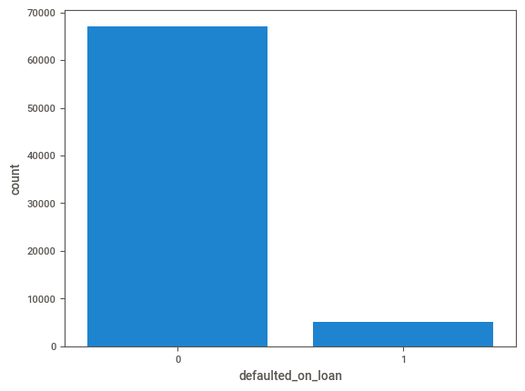

```python
sns.barplot(counted_df)
```

#### The data is unbalanced with respect with target value

```python
def plot_feature_distribution(df1, df2, label1, label2, features, rows):
    sns.set_style('whitegrid')

    # Create the grid properly
    fig, axes = plt.subplots(rows, 5, figsize=(20, 22))
    axes = axes.flatten() # Flatten so we can iterate with a single index

    for i, feature in enumerate(features):
        if i >= 100: break # Safety check for the 10x10 grid

        # Use kdeplot or histplot (Axes-level) instead of displot
        sns.kdeplot(df1[feature], ax=axes[i], label=label1, fill=True, warn_singular=False)
        sns.kdeplot(df2[feature], ax=axes[i], label=label2, fill=True, warn_singular=False)

        axes[i].set_xlabel(feature, fontsize=9)
        axes[i].tick_params(axis='x', labelsize=6)
        axes[i].tick_params(axis='y', labelsize=6)
        axes[i].set_ylabel('') # Remove 'Density' label to save space

    plt.tight_layout()
    plt.show()
```

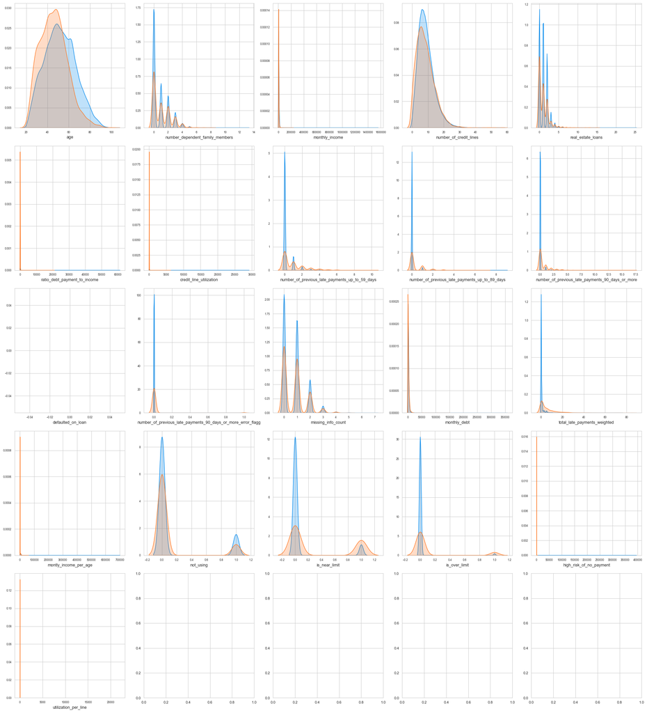

```python
# Execution
t0 = df.loc[df['defaulted_on_loan'] == 0]
t1 = df.loc[df['defaulted_on_loan'] == 1]
# Ensure you are only grabbing existing columns
features = df.columns
plot_feature_distribution(t0, t1, '0', '1', features, 5)
```

#### To transform, the data must have no gaps. Let's create flags for the gaps and fill them.

```python
cols_for_transform = ['credit_line_utilization', 'ratio_debt_payment_to_income', 'monthly_income', 'number_of_previous_late_payments_90_days_or_more_error_flagg',
                     'monthly_debt', 'total_late_payments_weighted', 'montly_income_per_age', 'high_risk_of_no_payment', 'utilization_per_line']
```

### Flagging

```python
for col in cols_for_transform:
    df[col+'_nan_flag'] = df[col].isna().astype(int)
```

### Imputing

```python
imputing = ColumnTransformer([
    ('s_imp', SimpleImputer(strategy='median'), cols_for_transform)
], remainder='passthrough', verbose_feature_names_out=False).set_output(transform='pandas')

df = imputing.fit_transform(df)
```

### Changing distribution

```python
pt = PowerTransformer(method='yeo-johnson')
for col in cols_for_transform:
    df[col] = pt.fit_transform(df[col].values.reshape(-1,1))
```

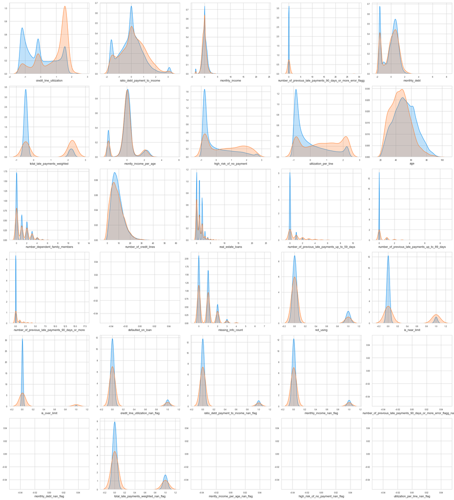

```python
t0 = df.loc[df['defaulted_on_loan'] == 0]
t1 = df.loc[df['defaulted_on_loan'] == 1]
features = df.columns
plot_feature_distribution(t0, t1, '0', '1', features, 6)
```

### Testing for multicollinearity

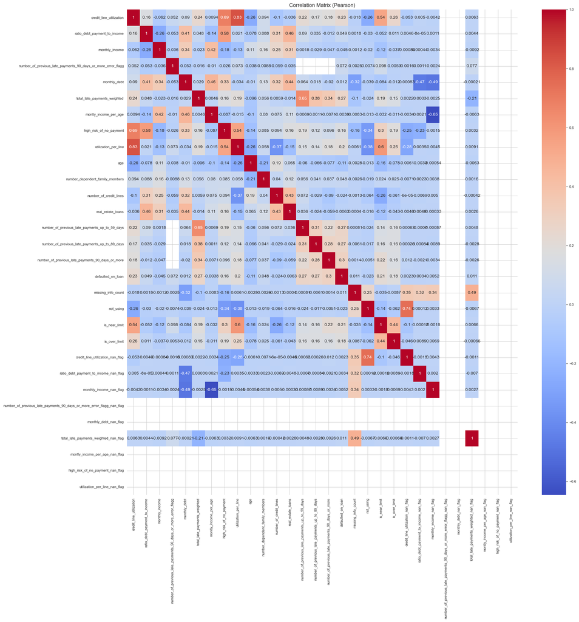

```python
correlation_matrix = df.corr()
plt.figure(figsize=(20,20))
sns.heatmap(correlation_matrix, annot=True, cmap="coolwarm")
plt.title("Correlation Matrix (Pearson)")
plt.show()
```

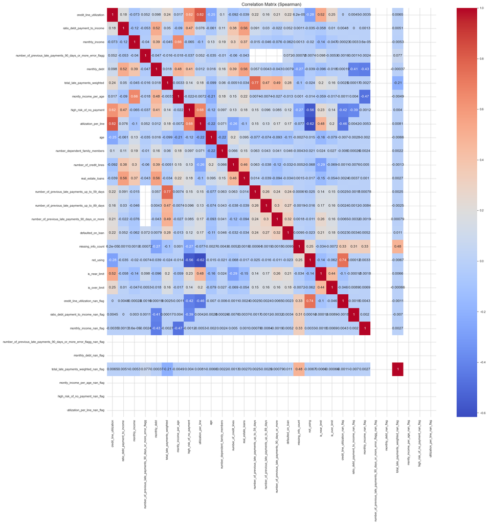

```python
spearman_correlation_matrix = df.corr(method="spearman")
plt.figure(figsize=(20,20))
sns.heatmap(spearman_correlation_matrix, annot=True, cmap="coolwarm")
plt.title("Correlation Matrix (Spearman)")
plt.show()
```

# Model evaluation

### Creating custom functions

```python
cols_for_transform = ['DisposableMonthlyIncomeRatio','credit_line_utilization', 'ratio_debt_payment_to_income', 'monthly_income', 'number_of_previous_late_payments_90_days_or_more_error_flagg',
                     'monthly_debt', 'total_late_payments_weighted', 'montly_income_per_age', 'high_risk_of_no_payment', 'utilization_per_line']
```

```python
def del_cols_and_rows(X):
    X_copy = X.copy(deep=True)

    X_copy = X_copy.drop(columns='Id')

    return X_copy

def column_convert(X):
    X_copy = X.copy(deep=True)

    converted_clu_col = X_copy['credit_line_utilization'].str.replace(',', '.').astype(float)
    converted_clu_col.apply(type).value_counts()
    X_copy['credit_line_utilization'] = converted_clu_col

    return X_copy

def error_handle(X):
    X_copy = X.copy(deep=True)

    late_pay_cols = ['number_of_previous_late_payments_up_to_59_days', 'number_of_previous_late_payments_up_to_89_days', 'number_of_previous_late_payments_90_days_or_more']

    X_copy['number_of_previous_late_payments_90_days_or_more_error_flagg'] = ((X_copy['number_of_previous_late_payments_90_days_or_more'] == 98) | (X_copy['number_of_previous_late_payments_90_days_or_more'] == 96)).astype(int)

    for col in late_pay_cols:
        X_copy[col] = X_copy[col].replace({96: np.nan, 98: np.nan})

    return X_copy
```

### Creating custom features

```python
def new_features(X):
    X_copy = X.copy(deep=True)

    if 'monthly_income' in X.columns and 'ratio_debt_payment_to_income' in X.columns:
        # Loan amount in currency
        X_copy['monthly_debt'] = X_copy['monthly_income'].fillna(0) * X_copy['ratio_debt_payment_to_income'].fillna(0)
        # The remaining money for a month after paying off the loan
        monthly_balance_after_pay = X_copy['monthly_income'].fillna(0) - X_copy['monthly_debt']
        # The ratio of remaining money for a month after paying off the loan and income
        X_copy['DisposableMonthlyIncomeRatio'] = (X_copy['monthly_income'].fillna(0) - X_copy['monthly_debt'].fillna(0)) / (X_copy['monthly_debt'].fillna(0) + 10e-6)

    if 'number_of_previous_late_payments_90_days_or_more' in X.columns and 'number_of_previous_late_payments_up_to_59_days' in X.columns and 'number_of_previous_late_payments_up_to_89_days' in X.columns:
        # Number of overdue payments with aggravation for duration
        X_copy['total_late_payments_weighted'] = 5 * X_copy['number_of_previous_late_payments_90_days_or_more'] + 1 * X_copy['number_of_previous_late_payments_up_to_59_days'] + 3 * X_copy['number_of_previous_late_payments_up_to_89_days']

    if 'monthly_income' in X.columns and 'age' in X.columns:
        # A person's success in their career. The older they are, the higher their income
        X_copy['montly_income_per_age'] = X_copy['monthly_income'].fillna(0) / (X_copy['age'].fillna(0) + 1)

    if 'credit_line_utilization' in X.columns:
        # Adding a flag indicating that the card is not in use or that incorrect data was entered
        X_copy['not_using'] = (X_copy['credit_line_utilization'].fillna(0) == 0.0).astype(int)
        # Adding a flag indicating that the credit card is almost completely used
        X_copy['is_near_limit'] = (X_copy['credit_line_utilization'].fillna(0) > 0.95).astype(int)
        # Adding a flag indicating that the use of funds exceeds the allowed limit on the credit card or that incorrect data was entered
        X_copy['is_over_limit'] = (X_copy['credit_line_utilization'].fillna(0) > 1.0).astype(int)

        if 'ratio_debt_payment_to_income' in X.columns:
            # High risk of default due to high credit card balances and a high loan-to-payment ratio
            X_copy['high_risk_of_no_payment'] = X_copy['credit_line_utilization'].fillna(0) * X_copy['ratio_debt_payment_to_income'].fillna(0)

        if 'number_of_credit_lines' in X.columns:
            # The percentage of funds spent on each open credit card is calculated separately.
            # If many are full, it's worse than if one is full
            X_copy['utilization_per_line'] = X_copy['credit_line_utilization'].fillna(0) / (X_copy['number_of_credit_lines'].fillna(0) + 1)


    return X_copy
```

### Loading the dataset and preparing the data

```python
df = pd.read_csv('train.csv')
test_df = pd.read_csv('test.csv')
```

```python
duplic_indx = df[df.duplicated()].index
df = df.drop(index=duplic_indx)
```

```python
X = df.drop(columns='defaulted_on_loan')
y = df['defaulted_on_loan']

X_train, X_test, y_train, y_test = train_test_split(X, y, test_size=0.1, random_state=30)
```

```python
del_cols_and_rows_t = FunctionTransformer(del_cols_and_rows)

convert_col_t = FunctionTransformer(column_convert)

error_handle_t = FunctionTransformer(error_handle)

new_features_t = FunctionTransformer(new_features)




pipeline_prep = Pipeline([
    ('deliter', del_cols_and_rows_t),
    ('converting_col', convert_col_t),
    ('errors_handler', error_handle_t),
    ('feture_engeniring', new_features_t),
])
```

```python
pipeline_prep.fit(X_train, y_train)
X_train_rep = pipeline_prep.transform(X_train)
X_test_prep = pipeline_prep.transform(X_test)
```

### Selecting hyperparameters for each model in the ensemble

```python
def objective(trial):
    param = {
        'iterations': trial.suggest_int("iterations", 100, 1000),
        'learning_rate': trial.suggest_float("learning_rate", 1e-3, 1e-1, log=True),
        'depth': trial.suggest_int("depth", 4, 10),
        'l2_leaf_reg': trial.suggest_float("l2_leaf_reg", 1e-8, 100.0, log=True),
        'bootstrap_type': trial.suggest_categorical("bootstrap_type", ["Bayesian"]),
        'random_strength': trial.suggest_float("random_strength", 1e-8, 10.0, log=True),
        'bagging_temperature': trial.suggest_float("bagging_temperature", 0.0, 10.0),
        'od_type': trial.suggest_categorical("od_type", ["IncToDec", "Iter"]),
        'od_wait': trial.suggest_int("od_wait", 10, 50),
        'scale_pos_weight': trial.suggest_int('scale_pos_weight', 12, 15),
        'random_seed': 7,
        'verbose': False,
        'allow_writing_files': False
        }

    model = CatBoostClassifier(**param)

    full_pipeline = Pipeline([
    ('deliter', del_cols_and_rows_t),
    ('converting_col', convert_col_t),
    ('errors_handler', error_handle_t),
    ('feture_engeniring', new_features_t),
    ('model', model)
    ])

    score = cross_val_score(full_pipeline, X, y, scoring='average_precision', cv=3, n_jobs=-1,).mean()

    return score
```

```python
study_1 = optuna.create_study(study_name='CatBoostClassifier', direction='maximize')
study_1.optimize(objective, n_trials=20, show_progress_bar=True)
best_params_cat = study_1.best_params
print('Best params:', best_params_cat)
```

```
[I 2026-05-07 18:15:35,204] A new study created in memory with name: CatBoostClassifier
```

```
[I 2026-05-07 18:15:44,631] Trial 0 finished with value: 0.33902226137337604 and parameters: {'iterations': 131, 'learning_rate': 0.005614704040268059, 'depth': 5, 'l2_leaf_reg': 0.3125420547638522, 'bootstrap_type': 'Bayesian', 'random_strength': 0.0015610130544245196, 'bagging_temperature': 4.5151…
[I 2026-05-07 18:15:59,675] Trial 1 finished with value: 0.34993132123584997 and parameters: {'iterations': 202, 'learning_rate': 0.009968048072922554, 'depth': 8, 'l2_leaf_reg': 5.210437813728541, 'bootstrap_type': 'Bayesian', 'random_strength': 8.18578421972362e-06, 'bagging_temperature': 2.384890…
[I 2026-05-07 18:16:45,894] Trial 2 finished with value: 0.3243157449871617 and parameters: {'iterations': 294, 'learning_rate': 0.001296573846482121, 'depth': 10, 'l2_leaf_reg': 2.1685952187001087e-05, 'bootstrap_type': 'Bayesian', 'random_strength': 6.715627237743246e-08, 'bagging_temperature': 1.…
[I 2026-05-07 18:16:55,746] Trial 3 finished with value: 0.3548044153965182 and parameters: {'iterations': 254, 'learning_rate': 0.07564586892407592, 'depth': 6, 'l2_leaf_reg': 0.0018570649179480432, 'bootstrap_type': 'Bayesian', 'random_strength': 0.015376450781967166, 'bagging_temperature': 5.5333…
[I 2026-05-07 18:17:19,263] Trial 4 finished with value: 0.3469164261740813 and parameters: {'iterations': 645, 'learning_rate': 0.0032285994676262367, 'depth': 6, 'l2_leaf_reg': 3.322190346760615e-06, 'bootstrap_type': 'Bayesian', 'random_strength': 1.1550213030636031e-07, 'bagging_temperature': 3.…
[I 2026-05-07 18:17:50,857] Trial 5 finished with value: 0.3440206666565981 and parameters: {'iterations': 382, 'learning_rate': 0.002670249625970659, 'depth': 9, 'l2_leaf_reg': 13.72306081151593, 'bootstrap_type': 'Bayesian', 'random_strength': 0.0028765209340253766, 'bagging_temperature': 9.595589…
[I 2026-05-07 18:18:19,874] Trial 6 finished with value: 0.34518220016412343 and parameters: {'iterations': 616, 'learning_rate': 0.001479838326907612, 'depth': 6, 'l2_leaf_reg': 0.16087947455266524, 'bootstrap_type': 'Bayesian', 'random_strength': 0.37292463307692636, 'bagging_temperature': 7.27142…
[I 2026-05-07 18:20:30,881] Trial 7 finished with value: 0.3284846223470044 and parameters: {'iterations': 747, 'learning_rate': 0.002772667228993792, 'depth': 10, 'l2_leaf_reg': 85.50735977391726, 'bootstrap_type': 'Bayesian', 'random_strength': 0.00042535270599535873, 'bagging_temperature': 8.6772…
[I 2026-05-07 18:20:59,898] Trial 8 finished with value: 0.34842363812388516 and parameters: {'iterations': 708, 'learning_rate': 0.08512541700643893, 'depth': 5, 'l2_leaf_reg': 4.0522466230013103e-07, 'bootstrap_type': 'Bayesian', 'random_strength': 0.003013396397213623, 'bagging_temperature': 2.83…
[I 2026-05-07 18:21:17,122] Trial 9 finished with value: 0.3464270446260979 and parameters: {'iterations': 524, 'learning_rate': 0.0036578484836980304, 'depth': 4, 'l2_leaf_reg': 2.869362177942147e-08, 'bootstrap_type': 'Bayesian', 'random_strength': 4.9076074885403076e-08, 'bagging_temperature': 7.…
[I 2026-05-07 18:21:40,550] Trial 10 finished with value: 0.3270299607768245 and parameters: {'iterations': 452, 'learning_rate': 0.07860008888309239, 'depth': 7, 'l2_leaf_reg': 0.002026365059401446, 'bootstrap_type': 'Bayesian', 'random_strength': 3.617672817565879, 'bagging_temperature': 5.6124632…
[I 2026-05-07 18:22:43,713] Trial 11 finished with value: 0.32186443924170083 and parameters: {'iterations': 994, 'learning_rate': 0.019846536030050262, 'depth': 8, 'l2_leaf_reg': 0.0012166088025695747, 'bootstrap_type': 'Bayesian', 'random_strength': 8.834038450731987e-06, 'bagging_temperature': 0.…
[I 2026-05-07 18:22:54,666] Trial 12 finished with value: 0.34528766770943786 and parameters: {'iterations': 150, 'learning_rate': 0.019057700199760018, 'depth': 8, 'l2_leaf_reg': 0.08623803269355085, 'bootstrap_type': 'Bayesian', 'random_strength': 4.187131120144283e-06, 'bagging_temperature': 4.07…
[I 2026-05-07 18:23:08,243] Trial 13 finished with value: 0.35346879597278735 and parameters: {'iterations': 268, 'learning_rate': 0.013994221009731151, 'depth': 7, 'l2_leaf_reg': 6.882629792818749e-05, 'bootstrap_type': 'Bayesian', 'random_strength': 0.081984076812752, 'bagging_temperature': 2.1390…
```

[output cut: 7 more lines]

```python
def objective(trial):
    param = {
        'objective': 'binary',

        'boosting_type': 'gbdt',
        'max_depth': trial.suggest_int('max_depth', 3, 12),
        'num_leaves': trial.suggest_int('num_leaves', 20, 150),
        'learning_rate': trial.suggest_float('learning_rate', 1e-3, 0.1, log=True),
        'n_estimators': trial.suggest_int('n_estimators', 500, 1500),
        'min_child_samples': trial.suggest_int('min_child_samples', 5, 100),
        'subsample': trial.suggest_float('subsample', 0.5, 0.9),
        'colsample_bytree': trial.suggest_float('colsample_bytree', 0.5, 0.9),
        'reg_alpha': trial.suggest_float('reg_alpha', 1e-8, 10.0, log=True),
        'reg_lambda': trial.suggest_float('reg_lambda', 1e-8, 10.0, log=True),
        'scale_pos_weight': trial.suggest_int('scale_pos_weight', 12, 15),
        'n_jobs': -1,
        'verbosity': -1,
        'random_state': 7,
        }

    model = lgb.LGBMClassifier(**param)

    full_pipeline = Pipeline([
    ('deliter', del_cols_and_rows_t),
    ('converting_col', convert_col_t),
    ('errors_handler', error_handle_t),
    ('feture_engeniring', new_features_t),
    ('model', model)
    ])

    score = cross_val_score(full_pipeline, X, y, scoring='average_precision', cv=3, n_jobs=-1,).mean()

    return score
```

```python
study_2 = optuna.create_study(study_name='LGBMClassifier', direction='maximize')
study_2.optimize(objective, n_trials=20, show_progress_bar=True)
best_params_lgbm = study_2.best_params
print('Best params:', best_params_lgbm)
```

```
[I 2026-05-07 18:24:48,057] A new study created in memory with name: LGBMClassifier
```

```
[I 2026-05-07 18:25:07,189] Trial 0 finished with value: 0.3459496791055933 and parameters: {'max_depth': 7, 'num_leaves': 111, 'learning_rate': 0.048046189792642656, 'n_estimators': 751, 'min_child_samples': 56, 'subsample': 0.7635417746341228, 'colsample_bytree': 0.5424234068795312, 'reg_alpha': 0…
[I 2026-05-07 18:25:30,579] Trial 1 finished with value: 0.35557853648130305 and parameters: {'max_depth': 7, 'num_leaves': 98, 'learning_rate': 0.034404673832650515, 'n_estimators': 1072, 'min_child_samples': 99, 'subsample': 0.6297423469286997, 'colsample_bytree': 0.5399019447787117, 'reg_alpha': …
[I 2026-05-07 18:25:48,538] Trial 2 finished with value: 0.3651330946115403 and parameters: {'max_depth': 4, 'num_leaves': 103, 'learning_rate': 0.0015044107235266148, 'n_estimators': 1310, 'min_child_samples': 95, 'subsample': 0.8147980887339188, 'colsample_bytree': 0.6533827033300998, 'reg_alpha':…
[I 2026-05-07 18:26:06,618] Trial 3 finished with value: 0.37432001804338316 and parameters: {'max_depth': 5, 'num_leaves': 90, 'learning_rate': 0.002268336314730513, 'n_estimators': 1161, 'min_child_samples': 30, 'subsample': 0.7065243575286709, 'colsample_bytree': 0.5783425906255542, 'reg_alpha': …
[I 2026-05-07 18:26:20,792] Trial 4 finished with value: 0.34659510123540277 and parameters: {'max_depth': 5, 'num_leaves': 92, 'learning_rate': 0.060730139478764024, 'n_estimators': 1167, 'min_child_samples': 95, 'subsample': 0.7288929044568996, 'colsample_bytree': 0.8713221901151651, 'reg_alpha': …
[I 2026-05-07 18:26:57,220] Trial 5 finished with value: 0.36653160632618037 and parameters: {'max_depth': 10, 'num_leaves': 80, 'learning_rate': 0.0015788503690070419, 'n_estimators': 1074, 'min_child_samples': 95, 'subsample': 0.7912040182126914, 'colsample_bytree': 0.8899789203212292, 'reg_alpha'…
[I 2026-05-07 18:27:13,250] Trial 6 finished with value: 0.3756829247880738 and parameters: {'max_depth': 5, 'num_leaves': 111, 'learning_rate': 0.0033729052483217965, 'n_estimators': 1069, 'min_child_samples': 21, 'subsample': 0.7042601076756625, 'colsample_bytree': 0.6088599040637608, 'reg_alpha':…
[I 2026-05-07 18:27:30,048] Trial 7 finished with value: 0.3769823924904711 and parameters: {'max_depth': 6, 'num_leaves': 135, 'learning_rate': 0.0033084472660548834, 'n_estimators': 885, 'min_child_samples': 57, 'subsample': 0.7406525481195477, 'colsample_bytree': 0.5390578055130079, 'reg_alpha': …
[I 2026-05-07 18:27:47,950] Trial 8 finished with value: 0.323951117504339 and parameters: {'max_depth': 10, 'num_leaves': 61, 'learning_rate': 0.058721713401551454, 'n_estimators': 832, 'min_child_samples': 20, 'subsample': 0.6066824017407342, 'colsample_bytree': 0.7608986713018628, 'reg_alpha': 2.…
[I 2026-05-07 18:28:00,788] Trial 9 finished with value: 0.34930975186549 and parameters: {'max_depth': 4, 'num_leaves': 115, 'learning_rate': 0.07650269251435692, 'n_estimators': 1237, 'min_child_samples': 65, 'subsample': 0.6213627804129525, 'colsample_bytree': 0.5577078956414055, 'reg_alpha': 3.8…
[I 2026-05-07 18:28:24,932] Trial 10 finished with value: 0.37367768595102024 and parameters: {'max_depth': 12, 'num_leaves': 150, 'learning_rate': 0.007438605283673401, 'n_estimators': 597, 'min_child_samples': 69, 'subsample': 0.8766780998853729, 'colsample_bytree': 0.7561629512092118, 'reg_alpha'…
[I 2026-05-07 18:28:41,677] Trial 11 finished with value: 0.3708167635921426 and parameters: {'max_depth': 6, 'num_leaves': 140, 'learning_rate': 0.00495279626576301, 'n_estimators': 871, 'min_child_samples': 6, 'subsample': 0.5443969869759311, 'colsample_bytree': 0.6391514453662355, 'reg_alpha': 1.…
[I 2026-05-07 18:29:05,341] Trial 12 finished with value: 0.3792566742233309 and parameters: {'max_depth': 9, 'num_leaves': 21, 'learning_rate': 0.003585590735946723, 'n_estimators': 1496, 'min_child_samples': 38, 'subsample': 0.6702808995427478, 'colsample_bytree': 0.5001919207526082, 'reg_alpha': …
[I 2026-05-07 18:29:25,198] Trial 13 finished with value: 0.37438969588044796 and parameters: {'max_depth': 9, 'num_leaves': 26, 'learning_rate': 0.012524001500738008, 'n_estimators': 1484, 'min_child_samples': 41, 'subsample': 0.6627461965950275, 'colsample_bytree': 0.5061955621559983, 'reg_alpha':…
```

[output cut: 7 more lines]

```python
def objective(trial):

    param = {
        'max_depth': trial.suggest_int('max_depth', 3, 7),
        'learning_rate': trial.suggest_float('learning_rate', 0.001, 0.008),
        'n_estimators': trial.suggest_int('n_estimators', 1500, 2500),
        'subsample': trial.suggest_float('subsample', 0.75, 1.0),
        'colsample_bytree': trial.suggest_float('colsample_bytree', 0.2, 0.8),
        'min_child_weight': trial.suggest_int('min_child_weight', 1, 7),
        'gamma': trial.suggest_float('gamma', 4, 10),
        'scale_pos_weight': trial.suggest_int('scale_pos_weight', 12, 15),
        'reg_alpha': trial.suggest_float('reg_alpha', 0.01, 0.06),
        'reg_lambda': trial.suggest_float('reg_lambda', 4.0, 15.0),
        'max_delta_step': trial.suggest_int('max_delta_step', 16, 24),
        "random_state": 6,
        "n_jobs": -1,
        'nthread': 4,
        'objective': 'binary:logistic',
    }

    model = XGBClassifier(**param)

    full_pipeline = Pipeline([
    ('deliter', del_cols_and_rows_t),
    ('converting_col', convert_col_t),
    ('errors_handler', error_handle_t),
    ('feture_engeniring', new_features_t),
    ('model', model)
])

    score = cross_val_score(full_pipeline, X, y, scoring='average_precision', cv=3, n_jobs=-1,).mean()

    return score
```

```python
study = optuna.create_study(study_name='XGBClassifier', direction='maximize')
study.optimize(objective, n_trials=20, show_progress_bar=True)
best_params_xgb = study.best_params
print('Best params:', best_params_xgb)
```

```
[I 2026-05-07 18:31:29,200] A new study created in memory with name: XGBClassifier
```

```
[I 2026-05-07 18:31:59,089] Trial 0 finished with value: 0.3789324824526288 and parameters: {'max_depth': 4, 'learning_rate': 0.004439254099654243, 'n_estimators': 1934, 'subsample': 0.8200856096682815, 'colsample_bytree': 0.6754038284020997, 'min_child_weight': 3, 'gamma': 5.523317868333662, 'scale…
[I 2026-05-07 18:32:29,624] Trial 1 finished with value: 0.3708920247184622 and parameters: {'max_depth': 3, 'learning_rate': 0.0021091777537750427, 'n_estimators': 2249, 'subsample': 0.7631548024646693, 'colsample_bytree': 0.590455543951395, 'min_child_weight': 2, 'gamma': 9.605840473285554, 'scale…
[I 2026-05-07 18:32:53,343] Trial 2 finished with value: 0.3756504307570389 and parameters: {'max_depth': 4, 'learning_rate': 0.0031555153456031167, 'n_estimators': 1618, 'subsample': 0.8868917513794264, 'colsample_bytree': 0.37965157472486727, 'min_child_weight': 4, 'gamma': 9.982206320165929, 'sca…
[I 2026-05-07 18:33:33,628] Trial 3 finished with value: 0.37567332005731896 and parameters: {'max_depth': 7, 'learning_rate': 0.0035239807390491616, 'n_estimators': 1886, 'subsample': 0.8799962767753275, 'colsample_bytree': 0.2576606054227898, 'min_child_weight': 6, 'gamma': 5.618159325323526, 'sca…
[I 2026-05-07 18:34:07,039] Trial 4 finished with value: 0.3775950593617863 and parameters: {'max_depth': 6, 'learning_rate': 0.0039478964918950536, 'n_estimators': 1600, 'subsample': 0.9023133239625858, 'colsample_bytree': 0.7843635873405399, 'min_child_weight': 6, 'gamma': 4.820542464319137, 'scal…
[I 2026-05-07 18:34:53,050] Trial 5 finished with value: 0.37836843878861465 and parameters: {'max_depth': 7, 'learning_rate': 0.004209001570017469, 'n_estimators': 2254, 'subsample': 0.8578740633592132, 'colsample_bytree': 0.4729002406624546, 'min_child_weight': 1, 'gamma': 8.253524044288648, 'scal…
[I 2026-05-07 18:35:29,962] Trial 6 finished with value: 0.3782225876674441 and parameters: {'max_depth': 6, 'learning_rate': 0.003362109649354342, 'n_estimators': 1953, 'subsample': 0.787013886574905, 'colsample_bytree': 0.30489678571533035, 'min_child_weight': 6, 'gamma': 9.433377399979152, 'scale…
[I 2026-05-07 18:35:58,231] Trial 7 finished with value: 0.3611440938374207 and parameters: {'max_depth': 4, 'learning_rate': 0.0010158784631125746, 'n_estimators': 1857, 'subsample': 0.7846598271923115, 'colsample_bytree': 0.27226480624859983, 'min_child_weight': 6, 'gamma': 8.61567343592884, 'scal…
[I 2026-05-07 18:36:29,169] Trial 8 finished with value: 0.3776749920445455 and parameters: {'max_depth': 6, 'learning_rate': 0.007623427478668369, 'n_estimators': 1897, 'subsample': 0.84244113994084, 'colsample_bytree': 0.21029394835689072, 'min_child_weight': 5, 'gamma': 9.189708787378205, 'scale_…
[I 2026-05-07 18:37:04,823] Trial 9 finished with value: 0.3777313790245956 and parameters: {'max_depth': 6, 'learning_rate': 0.003329747977881933, 'n_estimators': 1738, 'subsample': 0.9076847972961223, 'colsample_bytree': 0.613515570821257, 'min_child_weight': 3, 'gamma': 6.540965113838691, 'scale_…
[I 2026-05-07 18:37:30,770] Trial 10 finished with value: 0.3783671990995175 and parameters: {'max_depth': 3, 'learning_rate': 0.006032928734544011, 'n_estimators': 2088, 'subsample': 0.999473503759244, 'colsample_bytree': 0.7903516302346202, 'min_child_weight': 3, 'gamma': 4.048025264106617, 'scale…
[I 2026-05-07 18:38:07,756] Trial 11 finished with value: 0.3797931709994389 and parameters: {'max_depth': 4, 'learning_rate': 0.0054506497769076425, 'n_estimators': 2498, 'subsample': 0.8208731861852099, 'colsample_bytree': 0.4798204481878259, 'min_child_weight': 1, 'gamma': 7.919480442198783, 'sca…
[I 2026-05-07 18:38:45,708] Trial 12 finished with value: 0.3792519247015238 and parameters: {'max_depth': 4, 'learning_rate': 0.005393729836068473, 'n_estimators': 2499, 'subsample': 0.8034656595775597, 'colsample_bytree': 0.6413848695411009, 'min_child_weight': 1, 'gamma': 7.374156691796297, 'scal…
[I 2026-05-07 18:39:28,399] Trial 13 finished with value: 0.378685530863043 and parameters: {'max_depth': 5, 'learning_rate': 0.005663437707166906, 'n_estimators': 2496, 'subsample': 0.8191986643120437, 'colsample_bytree': 0.4679898601112916, 'min_child_weight': 1, 'gamma': 7.621196926445901, 'scale…
```

[output cut: 7 more lines]

### Creating an ensemble and train the final model

```python
best_params_cat = study_1.best_params
best_params_lgbm = study_2.best_params
best_params_xgb = study.best_params
```

```python
cat_m = CatBoostClassifier(**best_params_cat, logging_level= 'Silent')
lgbm_m = lgb.LGBMClassifier(**best_params_lgbm, verbosity= -1, verbose= -1,)
xgb_m = XGBClassifier(**best_params_xgb)

eclf = VotingClassifier(
    estimators=[('cat', cat_m), ('lgbm', lgbm_m), ('xgb', xgb_m)],
    voting='soft'
)
```

```python
pipeline_full = Pipeline([
    ('deliter', del_cols_and_rows_t),
    ('converting_col', convert_col_t),
    ('errors_handler', error_handle_t),
    ('feture_engeniring', new_features_t),
    ('ensemble', eclf)
])
cross_val_score(pipeline_full, X, y, scoring='roc_auc', cv=5, n_jobs=-1, error_score='raise').mean()
```

```
np.float64(0.8476970113391946)
```

```python
pipeline_full.fit(X_train, y_train)
y_pred = pipeline_full.predict(X_test)
```

```python
print(classification_report(y_test, y_pred))
```

```
              precision    recall  f1-score   support

           0       0.98      0.81      0.89      6735
           1       0.22      0.73      0.33       482

    accuracy                           0.81      7217
   macro avg       0.60      0.77      0.61      7217
weighted avg       0.93      0.81      0.85      7217
```

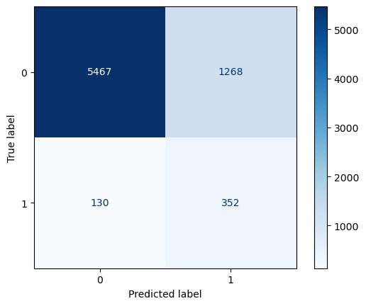

```python
cm = confusion_matrix(y_test, y_pred)
disp = ConfusionMatrixDisplay(cm)
disp.plot(cmap=plt.cm.Blues)
plt.show()
```

### Using shap to explain the model

```python
explainer = shap.TreeExplainer(pipeline_full['ensemble'].estimators_[0])
shap_values = explainer(X_test_prep)
```

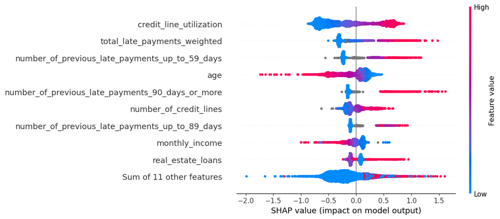

```python
shap.plots.beeswarm(shap_values)
```

#### The graph above shows that the models relied most on the following features: credit_line_utilization, total_late_payments_weighted. It sounds logical enough that you can't trust people who have already had significant delinquencies and who have completely used up their credit cards without leaving any reserves.

#### You can also see from the graph that higher values indicate a higher probability of default. However, there are a couple of features that show the opposite pattern.

```python
shap_total = shap_values.values.sum(axis=1)
shap_df = pd.DataFrame({
    'shap_sum': shap_total,
    'base_value': shap_values.base_values
})
shap_df['prediction'] = shap_df['base_value'] + shap_df['shap_sum']
shap_df['y_true'] = y_test.reset_index(drop=True)
shap_df['y_pred'] = y_pred
```

```python
shap_df[(shap_df['y_true'] ==1) & (shap_df['y_pred'] ==0)]
```

|  | shap_sum | base_value | prediction | y_true | y_pred |
| --- | --- | --- | --- | --- | --- |
| 63 | -0.749722 | -0.076376 | -0.826098 | 1 | 0 |
| 133 | -0.609293 | -0.076376 | -0.685669 | 1 | 0 |
| 157 | -1.778572 | -0.076376 | -1.854948 | 1 | 0 |
| 234 | 0.111345 | -0.076376 | 0.034969 | 1 | 0 |
| 313 | -0.206381 | -0.076376 | -0.282757 | 1 | 0 |
| ... | ... | ... | ... | ... | ... |
| 6929 | -0.148565 | -0.076376 | -0.224941 | 1 | 0 |
| 6933 | -0.063709 | -0.076376 | -0.140085 | 1 | 0 |
| 6943 | -1.001909 | -0.076376 | -1.078284 | 1 | 0 |
| 6986 | -1.620767 | -0.076376 | -1.697142 | 1 | 0 |
| 7112 | -1.558482 | -0.076376 | -1.634858 | 1 | 0 |

130 rows × 5 columns

```
True: 1, Pred: 0
```

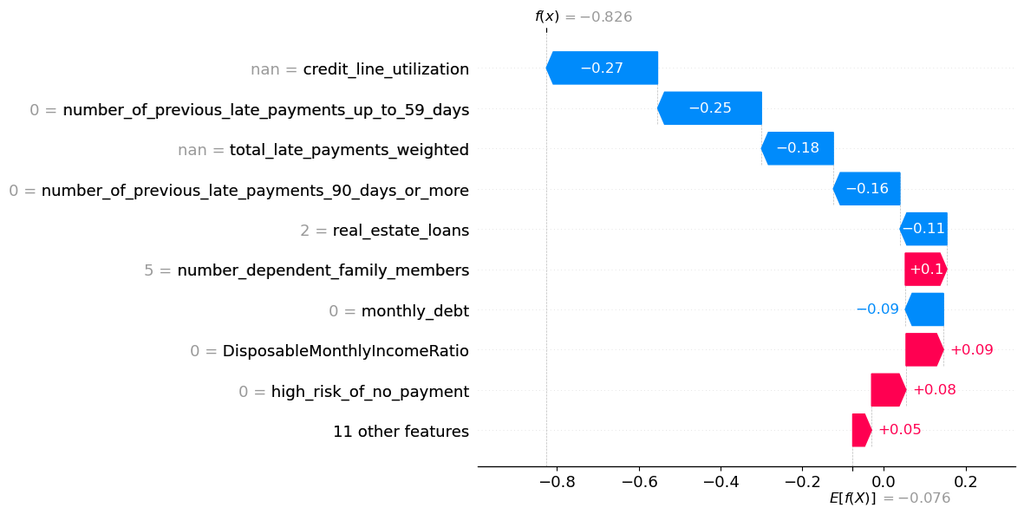

```python
print('True: 1, Pred: 0')
shap.plots.waterfall(shap_values[63])
```

#### I think this prediction was unsuccessful because the model uses NaN as a risk-mitigating parameter, but I would change my approach. The lack of data may indicate a user's reluctance to provide it, which naturally increases the risk of default.

```
True: 0, Pred: 1
```

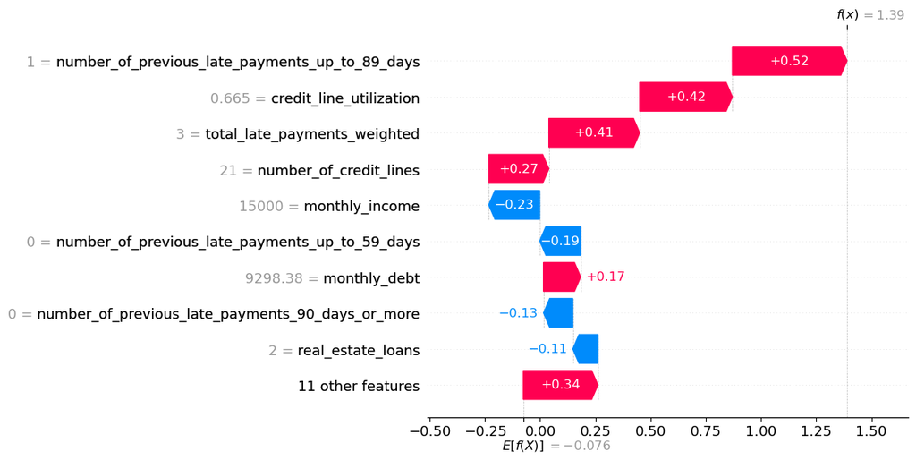

```python
print('True: 0, Pred: 1')
shap.plots.waterfall(shap_values[0])
```

#### Here, in my opinion, the scales were arranged more or less logically. Additional features could have been added that would have brought the model closer to Class 0.

```
True: 0, Pred: 0
```

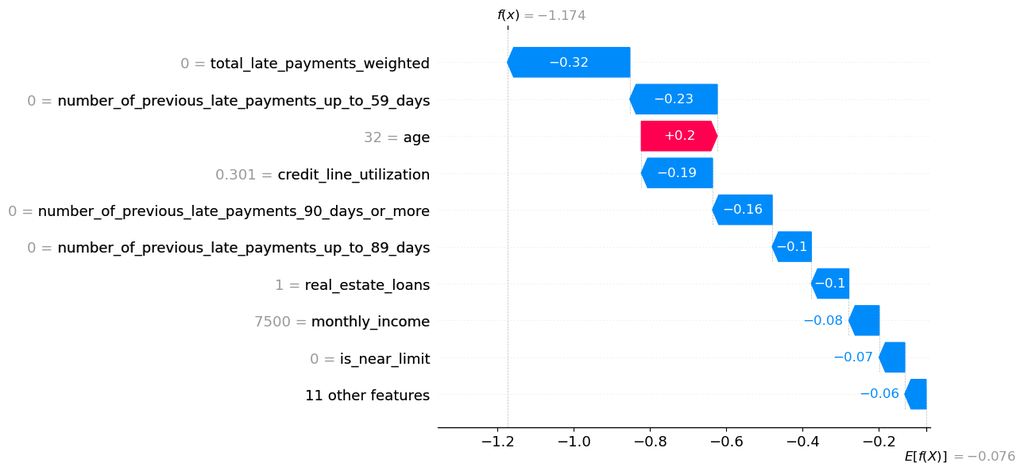

```python
print('True: 0, Pred: 0')
shap.plots.waterfall(shap_values[1])
```

```
True: 1, Pred: 1
```

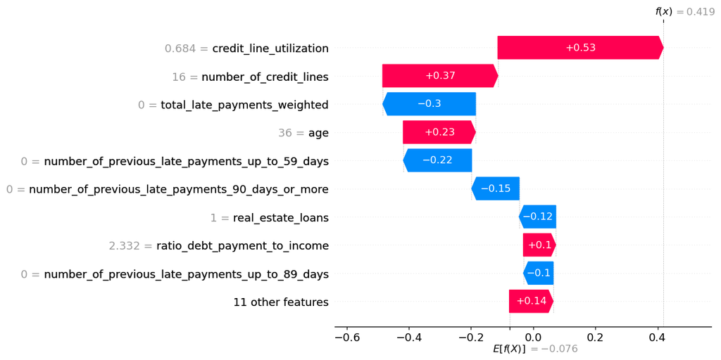

```python
print('True: 1, Pred: 1')
shap.plots.waterfall(shap_values[22])
```

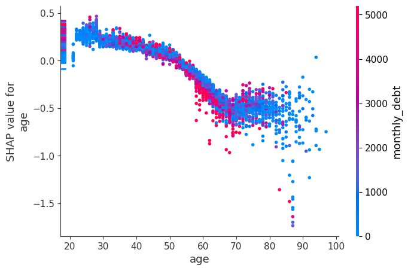

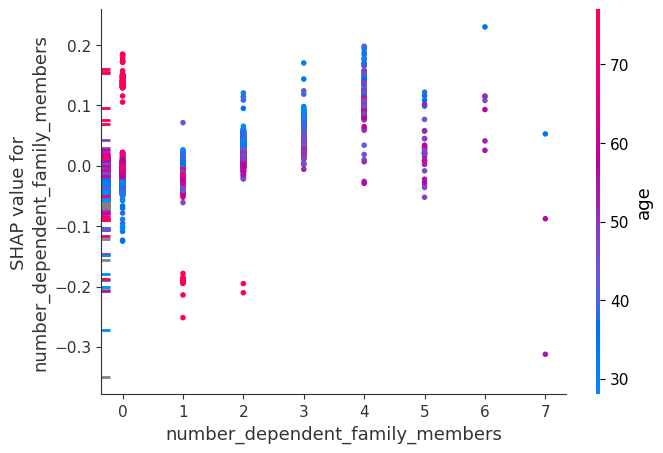

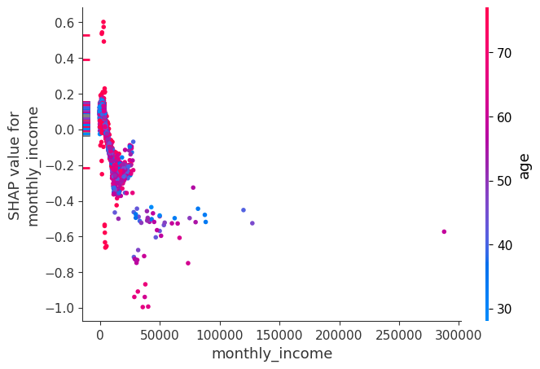

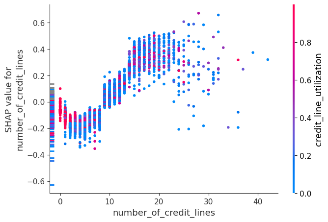

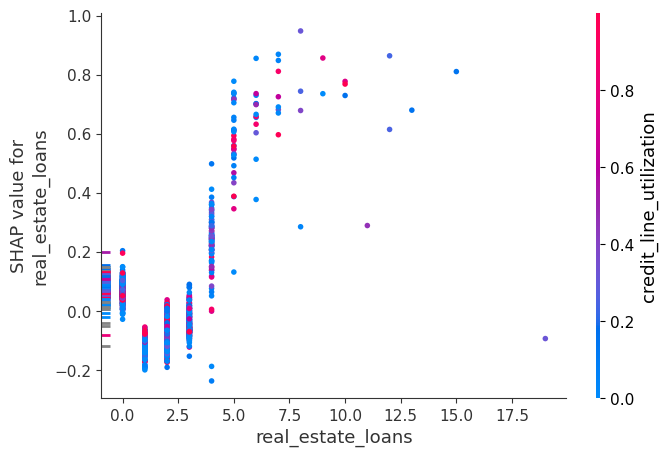

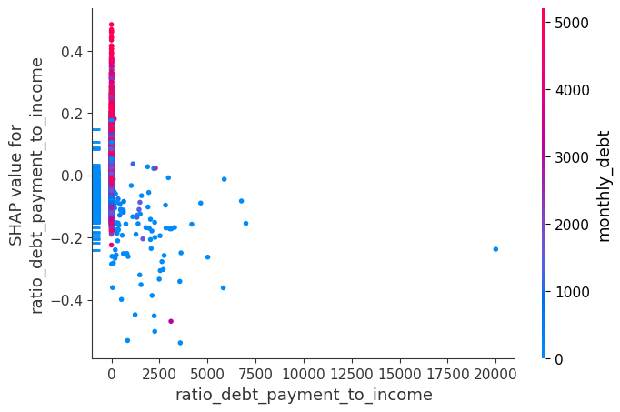

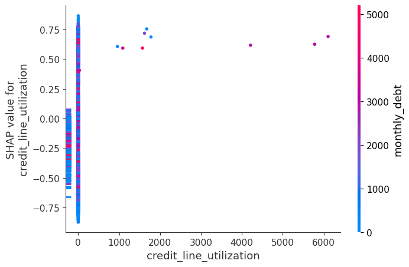

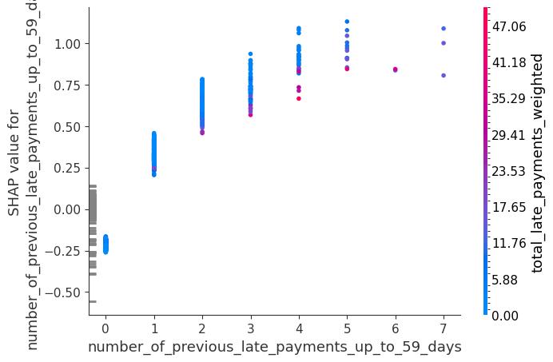

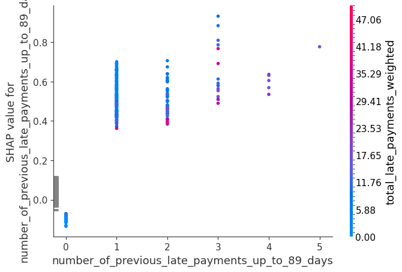

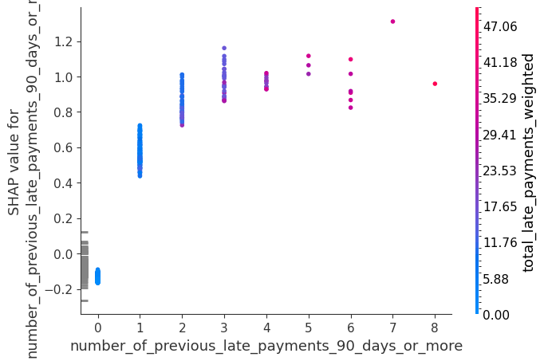

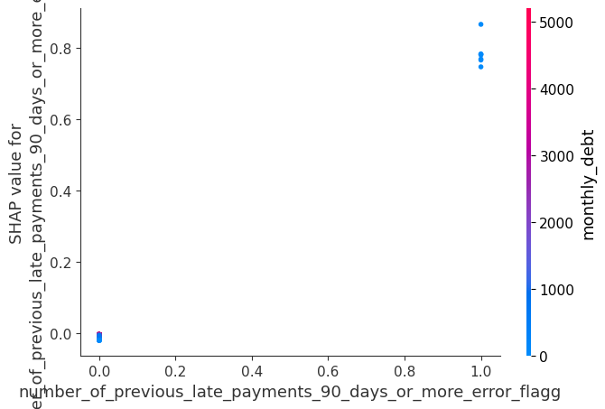

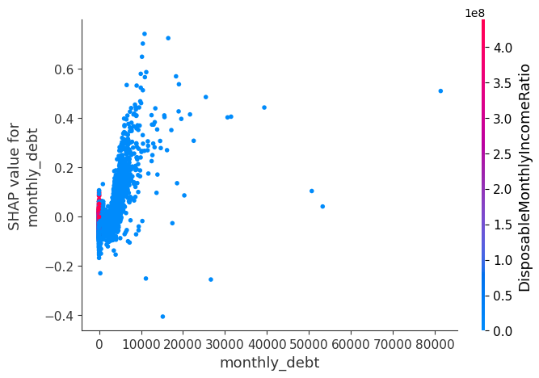

[8 more figures not shown]

```python
cols = X_test_prep.columns
for col in cols:
    shap.dependence_plot(col, shap_values.values, X_test_prep)
```

#### Most of the columns show convincing and credible results, although there are some surprises—for example, a feature that should indicate increased default risk actually reduces it.